# ts-8-hierarchical-time-series

**If you think this notebook deserves an upvote, I'd love to have it. An upvote per view, its all I ask** (credit to [Dan Carlin](https://twitter.com/HardcoreHistory) for coining the phrase ;-)

This is part of a series of notebooks about practical time series methods:

- [Part 0: the basics](https://www.kaggle.com/konradb/ts-0-the-basics)
- [Part 1a: smoothing methods](https://www.kaggle.com/konradb/ts-1a-smoothing-methods)
- [Part 1b: Prophet](https://www.kaggle.com/konradb/ts-1b-prophet)
- [Part 2: ARMA](https://www.kaggle.com/konradb/ts-2-arma-and-friends)
- [Part 3: Time series for finance](https://www.kaggle.com/konradb/ts-3-time-series-for-finance)
- [Part 4: Sales and demand forecasting](https://www.kaggle.com/konradb/ts-4-sales-and-demand-forecasting)
- [Part 5: Automatic for the people](https://www.kaggle.com/code/konradb/ts-5-automatic-for-the-people)
- [Part 6: Deep learning for TS - sequences](https://www.kaggle.com/konradb/ts-6-deep-learning-for-ts-sequences)
- [Part 7: Survival analysis](https://www.kaggle.com/konradb/ts-7-survival-analysis)
- [Part 8: Hierarchical time series](https://www.kaggle.com/konradb/ts-8-hierarchical-time-series) - **this notebook**
- [Part 9: Hybrid methods](https://www.kaggle.com/code/konradb/ts-9-hybrid-methods/)
- [Part 10: Validation methods for time series](https://www.kaggle.com/code/konradb/ts-10-validation-methods-for-time-series/)
- [Part 11: Transfer learning](https://www.kaggle.com/code/konradb/ts-11-deep-learning-for-ts-transfer-learning)

The series is accompanied by video presentations on the YouTube channel of [Abhishek](https://www.kaggle.com/abhishek):

- [Talk 0](https://www.youtube.com/watch?v=cKzXOOtOXYY)
- [Talk 1](https://www.youtube.com/watch?v=kAI67Sz92-s) - combining the content from parts 1a and 1b
- [Talk 2](https://www.youtube.com/watch?v=LjV5DE3KR-U)
- [Talk 3](https://www.youtube.com/watch?v=74rDhJexmTg)
- [Talk 4](https://www.youtube.com/watch?v=RdH8zd07u2E)
- [Talk 5](https://www.youtube.com/watch?v=wBP8Pc4Wxzs)
- [Talk 6](https://www.youtube.com/watch?v=81AEI0tj0Kk)
- [Talk 7](https://www.youtube.com/watch?v=m-8I_hkmz9o)
- [Talk 8](https://www.youtube.com/watch?v=7ZTarg4QYR4) - **based on this notebook**
- [Talk 9](https://www.youtube.com/watch?v=NYZzBvKcfp4)
- [Talk 10](https://www.youtube.com/watch?v=47WeBiLV2Uo)
- [Talk 11](https://www.youtube.com/watch?v=izcmIemT-rU)

Hierarchical structures are all around us: at work, at home, in sports, in Jordan Peterson lectures - and most interestingly from the point of view of this talk, in time series data. Whether you are dealing with supply chain, sales or tourism (or other examples that escape me), your time series is likely to have some sort of hierarchical structure that can be exploited for predict the future more accurately. In this episode we will talk about the different methods for reconciliation of hierarchical time series: combining the forecasts at different levels of aggregation in a consistent and efficient manner.

```python
!pip install hierarchicalforecast statsforecast datasetsforecast
```

```python
import numpy as np
import pandas as pd
import os


from datasetsforecast.hierarchical import HierarchicalData
from hierarchicalforecast.core import HierarchicalReconciliation
from hierarchicalforecast.methods import  BottomUp, TopDown, MiddleOut, MinTrace, ERM
from statsforecast.core import StatsForecast
from statsforecast.models import AutoARIMA, Naive
from hierarchicalforecast.evaluation import HierarchicalEvaluation

from sklearn.metrics import mean_squared_error as mse

import matplotlib.pyplot as plt
%matplotlib inline
plt.style.use('fivethirtyeight')
```

```python
# general settings
class CFG:
    data_folder = '../input/tsdata-1/'
    img_dim1 = 20
    img_dim2 = 10

# adjust the parameters for displayed figures
plt.rcParams.update({'figure.figsize': (CFG.img_dim1,CFG.img_dim2)})
```

```python
def my_rmse(x,y):
    return(np.round( np.sqrt(mse(x.values,y.values)) ,4))
```

# Why are we here?

## Hierarchical time series

- time series in various application have a natural hierarchy (a level structure):

[source](https://towardsdatascience.com/forecast-reconciliation-in-python-8203c16254b2)

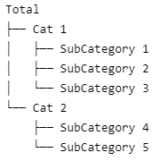

- SC1 exclusively under C1, SC4 under C2 $\implies$ **hierarchical time series**
- non exclusive $\implies$ grouped time series (not naturally disaggregating in a unique hierarchical manner)

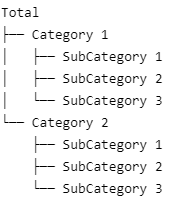

- additive across levels: in a manner consistent with the aggregation structure

\begin{equation} T = C_1 + C_2 \\ C_1 = SC_1 + SC_2 + SC_3 \\ C_2 = SC_4 + SC_5 \end{equation}

- most time series methods focus on a particular level of aggregation, but fail to address drilling down to a more granular level.
- sum of lower level $\neq$ higher level $\implies$ incoherent forecast
- enter HTS
- **not a methodology** (like ARIMA, ETS, Prophet) but a collection of techniques to achieve coherence
- hierarchy components can interact $\implies$ simultaneous modeling yields higher quality forecasts

Why are forecasts incoherent?

1. correct high level forecasts, issues at low levels
2. correct low level forecasts, issues with aggregation
3. combination of 1. and 2.

## The setup

In order to ensure forecast coherence we need to break our hierarchical time series into components

### Base Forecasts

We build univariate forecasts at each individual level across the hierarchy.

### Summing matrix

- The summing matrix describes the hierarchical structure of the data
- columns = unique series on the bottom level
- rows = unique series across all levels
- values = 0/1 $\rightarrow$ which bottom-level (column) categories map to each of the hierarchies across all levels. Since picture $\gg$ 1000 words:

[source](https://towardsdatascience.com/forecast-reconciliation-in-python-8203c16254b2)

[figure not shown]

### Mapping Matrix

- multiply by summing matrix and based forecast $\implies$ coherent forecasts
- objective: reconcile the forecasts with minimal variance
- Varies per reconciliation method used

# Data groundwork

In this notebook we will be using data from the [M5 competition](https://www.kaggle.com/competitions/m5-forecasting-accuracy) described on the competition website thus:

"*In this competition, the fifth iteration, you will use hierarchical sales data from Walmart, the world’s largest company by revenue, to forecast daily sales for the next 28 days. The data, covers stores in three US States (California, Texas, and Wisconsin) and includes item level, department, product categories, and store details. In addition, it has explanatory variables such as price, promotions, day of the week, and special events. Together, this robust dataset can be used to improve forecasting accuracy.*"

For the sake of this demonstration, we will subset the data to sales of a single product across all Walmart stores in the period of interest. There are quite a few hts solutions floating around, after some thought I decided to for `hierarchicalforecast`: https://github.com/Nixtla/hierarchicalforecast. It does require a little preparation work (creating the baseline forecasts, summing matrix etc) but the ease of use makes it worth the effort.

We begin by creating the baseline forecasts:

```python
# sales data calendar_df = pd.read_csv('../input/m5-forecasting-accuracy/calendar.csv', parse_dates=['date'])
calendar_df = pd.read_csv('../input/m5-forecasting-accuracy/calendar.csv', parse_dates=['date'])
calendar_df = calendar_df.loc[:, ['date', 'wm_yr_wk', 'd']]
df = pd.read_csv('../input/m5-forecasting-accuracy/sales_train_evaluation.csv')
df = df.loc[df.item_id=='FOODS_3_819']
df_T = df.melt(id_vars=['id', 'item_id', 'dept_id', 'cat_id', 'store_id', 'state_id'])
df_T.drop(columns=['id'], inplace=True)

sales_df = df_T.merge(calendar_df, left_on='variable', right_on='d', how='left')
sales_df.rename(columns={'value': 'sales_qty'}, inplace=True)
df = sales_df.loc[sales_df.date >= '2014-01-01', ['date', 'store_id', 'sales_qty']]
df['state_id'] = df['store_id'].str[:2]

df.head(3)
```

```python
# create the long format matrix: individual stores
df_ind = df.groupby(['date', 'store_id'])[['sales_qty']].sum()
df_ind.reset_index(inplace=True)
df_ind = df_ind.T.reset_index(drop=True).T
df_ind.columns = ['ds', 'unique_id', 'sales']

# create the long format matrix: state level
df_sta = df.groupby(['date', 'state_id'])[['sales_qty']].sum()
df_sta.reset_index(inplace=True)
df_sta.columns = ['ds', 'unique_id', 'sales']

# create the long format matrix: total level
df_tot = df.groupby(['date'])[['sales_qty']].sum()
df_tot.reset_index(inplace=True)
df_tot['unique_id'] = 'Total'
df_tot.columns = ['ds', 'sales', 'unique_id' ]


# combine all three
dfx = pd.concat([df_ind, df_sta, df_tot], axis = 0)
print(df_ind.shape, df_sta.shape, df_tot.shape, dfx.shape)

# format
xset = set(dfx.unique_id)
dfx.columns = ['ds','unique_id', 'y']
dfx['ds'] = pd.to_datetime(dfx['ds'])
dfx.head(10)
```

The steps above give us a dataframe representing a hierarchical structure:

\begin{equation} Total = CA + TX + WI \\ CA = CA_1 + CA_2 + CA_3 + CA_4 \\ TX = TX_1 + TX_2 + TX_3 \\ WI = WI_1 + WI_2 + WI_3 \\ \end{equation}

Next step is the summing matrix: recall that $S$ is an $m$x$n$ matrix where $m$ = number of unique series across all levels (stores + states + total) and $n$ = (stores)

```python
S = np.zeros((len(xset), len([f for f in xset if '_' in f])))


# rows / columns
list1 = ['Total', 'CA','CA_1','CA_2','CA_3','CA_4','TX','TX_1','TX_2','TX_3','WI','WI_1','WI_2','WI_3']
list2 = ['CA_1','CA_2','CA_3','CA_4','TX_1','TX_2','TX_3','WI_1','WI_2','WI_3']
S = pd.DataFrame(S); S.index = list1; S.columns = list2


# encode the hierarchical structure
S.loc['Total'] = 1
S.loc['CA'][['CA_1','CA_2','CA_3', 'CA_4']] = 1
S.loc['TX'][['TX_1','TX_2','TX_3']] = 1
S.loc['WI'][['WI_1','WI_2','WI_3']] = 1
for x in S.columns:
    S.loc[x][x]= 1
S = S.astype(int)
S
```

The `hierarchicalforecast` implementation requires tags: a dictionary describing the composition of each level:

```python
tags = {}
tags['Country'] = np.array(['Total'], dtype=object)
tags['Country/State'] = np.array(['CA', 'TX', 'WI'], dtype=object)
tags['Country/State/Store'] = np.array(['CA_1', 'CA_2', 'CA_3', 'CA_4',
                                        'TX_1', 'TX_2', 'TX_3',
                                        'WI_1', 'WI_2', 'WI_3'], dtype=object)
tags
```

We have the hierarchical setup ready, so let us build a set of baseline forecasts: we will use the last 7 days as test set.

```python
horizon = 7

x_test = dfx.groupby('unique_id').tail(horizon)
x_train = dfx.drop(x_test.index)
x_test = x_test.set_index('unique_id')
x_train = x_train.set_index('unique_id')
```

```python
# Compute base auto-ARIMA predictions
fcst = StatsForecast(df = x_train, models=[AutoARIMA(season_length= 7)], freq='D', n_jobs=-1)
x_hat = fcst.forecast(h = horizon)
```

What do error metrics look like for the raw (unreconciled) forecasts?

```python
xmat = pd.merge(left = x_test, right = x_hat, on = ['ds', 'unique_id'])
xmat.head(3)
```

```python
xmat = pd.merge(left = x_test, right = x_hat, on = ['ds', 'unique_id'])
xmat.columns = [['ds', 'y', 'pred']]
print('overall rmse: ' + str(my_rmse(xmat['y'], xmat['pred'])))
for k in tags.keys():
    print(k + ' rmse: ' + str(my_rmse(xmat.loc[tags[k]]['y'], xmat.loc[tags[k]]['pred'])))
```

# BottomUp

- forecast each of the disaggregated series at the lowest level of the hierarchy
- add up to the higher levels

[Source](https://medium.com/opex-analytics/hierarchical-time-series-101-734a3da15426):

[figure not shown]

```python
# Reconcile the base predictions
reconcilers = [
    BottomUp()
]

hrec = HierarchicalReconciliation(reconcilers = reconcilers)
#x_hat_rec = hrec.reconcile(x_hat, x_train, S, tags)
x_hat_rec = hrec.reconcile(x_hat, S, tags)
```

```python
def mse(y, y_hat):
    return np.mean((y-y_hat)**2)

evaluator = HierarchicalEvaluation(evaluators=[mse])
evaluator.evaluate(Y_hat_df = x_hat_rec, Y_test_df = x_test,
                   tags=tags, benchmark='AutoARIMA')
```

```python
xmat = pd.merge(left = x_test, right = x_hat_rec, on = ['ds', 'unique_id'])
xmat.head(3)
```

```python
xmat = pd.merge(left = x_test, right = x_hat_rec, on = ['ds', 'unique_id'])
xmat.columns = [['ds', 'y', 'pred_orig', 'pred_reconciled']]
mse1 = my_rmse(xmat['y'], xmat['pred_orig'])
mse2 = my_rmse(xmat['y'], xmat['pred_reconciled'])
print('overall rmse: ' + str(mse1) + ' -> ' + str(mse2))

for k in tags.keys():
    mse1 = my_rmse(xmat.loc[tags[k]]['y'], xmat.loc[tags[k]]['pred_orig'])
    mse2 = my_rmse(xmat.loc[tags[k]]['y'], xmat.loc[tags[k]]['pred_reconciled'])

    print(k + ' rmse: ' + str(mse1) + ' -> ' + str(mse2) )
```

- no information lost due to aggregation
- ignores relationships between series
- lower levels can be noisy

# TopDown

This approach is the opposite of the previous one: we forecast the highest level series and the disaggregate it based on proportions:

- average historical proportions: \begin{equation*} p_j = \frac{1}{T} \sum_{t=1}^T \frac{y_{j,t}}{y_t} \end{equation*}
- proportions of historical averages: \begin{equation*} p_j = \frac{\sum_{t=1}^T \frac{y_{j,t}}{T}}{\sum_{t=1}^T \frac{y_{t}}{y_t}} \end{equation*}

[Source](https://medium.com/opex-analytics/hierarchical-time-series-101-734a3da15426):

[figure not shown]

```python
# Reconcile the base predictions
reconcilers = [
    TopDown(method='forecast_proportions')
]

hrec = HierarchicalReconciliation(reconcilers = reconcilers)
# x_hat_rec = hrec.reconcile(x_hat, x_train, S, tags)
x_hat_rec = hrec.reconcile(x_hat, S, tags)
```

```python
evaluator = HierarchicalEvaluation(evaluators=[mse])
evaluator.evaluate(Y_hat_df = x_hat_rec, Y_test_df = x_test,
                   tags=tags, benchmark='AutoARIMA')
```

```python
xmat = pd.merge(left = x_test, right = x_hat_rec, on = ['ds', 'unique_id'])
xmat.columns = [['ds', 'y', 'pred_orig', 'pred_reconciled']]
mse1 = my_rmse(xmat['y'], xmat['pred_orig'])
mse2 = my_rmse(xmat['y'], xmat['pred_reconciled'])
print('overall rmse: ' + str(mse1) + ' -> ' + str(mse2))

for k in tags.keys():
    mse1 = my_rmse(xmat.loc[tags[k]]['y'], xmat.loc[tags[k]]['pred_orig'])
    mse2 = my_rmse(xmat.loc[tags[k]]['y'], xmat.loc[tags[k]]['pred_reconciled'])

    print(k + ' rmse: ' + str(mse1) + ' -> ' + str(mse2) )
```

# MiddleOut

This approach combines the previous two:

- bottom-up and top-down together
- pick a middle level, use bottoms-up to find overall sales
- disintegrate sales using proportion to find the most granual level values

[Source](https://medium.com/opex-analytics/hierarchical-time-series-101-734a3da15426):

[figure not shown]

```python
# Reconcile the base predictions
reconcilers = [
    MiddleOut(middle_level = 'Country/State', top_down_method='forecast_proportions')
]

hrec = HierarchicalReconciliation(reconcilers = reconcilers)
# x_hat_rec = hrec.reconcile(x_hat, x_train, S, tags).fillna(0)
x_hat_rec = hrec.reconcile(x_hat, S, tags).fillna(0)
```

```python
evaluator = HierarchicalEvaluation(evaluators=[mse])
evaluator.evaluate(Y_hat_df = x_hat_rec, Y_test_df = x_test,
                   tags=tags, benchmark='AutoARIMA')
```

```python
xmat = pd.merge(left = x_test, right = x_hat_rec, on = ['ds', 'unique_id'])
xmat.columns = [['ds', 'y', 'pred_orig', 'pred_reconciled']]
mse1 = my_rmse(xmat['y'], xmat['pred_orig'])
mse2 = my_rmse(xmat['y'], xmat['pred_reconciled'])
print('overall rmse: ' + str(mse1) + ' -> ' + str(mse2))

for k in tags.keys():
    mse1 = my_rmse(xmat.loc[tags[k]]['y'], xmat.loc[tags[k]]['pred_orig'])
    mse2 = my_rmse(xmat.loc[tags[k]]['y'], xmat.loc[tags[k]]['pred_reconciled'])

    print(k + ' rmse: ' + str(mse1) + ' -> ' + str(mse2) )
```

# MinTrace

- predict for all the layers independently
- construct a mapping matrix minimising the overall variance of the forecasts
- assumes forecasts are unbiased
- original paper: https://www.tandfonline.com/doi/abs/10.1080/01621459.2018.1448825?journalCode=uasa20

[Source](https://medium.com/opex-analytics/hierarchical-time-series-101-734a3da15426):

[figure not shown]

```python
# Reconcile the base predictions
reconcilers = [
    MinTrace(method='ols'),
]

hrec = HierarchicalReconciliation(reconcilers = reconcilers)
# x_hat_rec = hrec.reconcile(x_hat, x_train, S, tags)
x_hat_rec = hrec.reconcile(x_hat, S, tags)
```

```python
print(x_hat.shape, x_train.shape)
```

```python
evaluator = HierarchicalEvaluation(evaluators=[mse])
evaluator.evaluate(Y_hat_df = x_hat_rec, Y_test_df = x_test,
                   tags=tags, benchmark='AutoARIMA')
```

```python
xmat = pd.merge(left = x_test, right = x_hat_rec, on = ['ds', 'unique_id'])
xmat.columns = [['ds', 'y', 'pred_orig', 'pred_reconciled']]
mse1 = my_rmse(xmat['y'], xmat['pred_orig'])
mse2 = my_rmse(xmat['y'], xmat['pred_reconciled'])
print('overall rmse: ' + str(mse1) + ' -> ' + str(mse2))

for k in tags.keys():
    mse1 = my_rmse(xmat.loc[tags[k]]['y'], xmat.loc[tags[k]]['pred_orig'])
    mse2 = my_rmse(xmat.loc[tags[k]]['y'], xmat.loc[tags[k]]['pred_reconciled'])

    print(k + ' rmse: ' + str(mse1) + ' -> ' + str(mse2) )
```

# Use case

Let's see how this approach performs on a dataset with more levels in the hierarchy: Greek beverage sales https://www.kaggle.com/datasets/veeralakrishna/predict-demand

```python
xdat = pd.read_csv('../input/predict-demand/train.csv', nrows= 6480)
xdat['date'] = pd.to_datetime(xdat['date'])
xdat.head(3)
```

Data preparation:

```python
# wee bit cleanup
xdat['shop'] = xdat['shop'].apply(lambda s: s.replace('_',''))

# NA
xdat['container'] = xdat['container'].fillna('unk')
xdat['capacity'] = xdat['capacity'].fillna('unk')

# sanity check
for f in ['city','shop', 'brand', 'container', 'capacity']:
    print(f)
    print(xdat[f].unique())
```

```python
# create unique identifiers per level in the hierarchy
xdat['shop'] = xdat['city'] + '_' + xdat['shop']
xdat['brand'] = xdat['shop'] + '_' + xdat['brand']
xdat['container'] = xdat['brand'] + '_' + xdat['container']
xdat['capacity'] = xdat['container'] + '_' + xdat['capacity']
xdat.head(3)
```

```python
# drop rows with insufficient amount of observations - the prediction methods in StatsForecast do not allow NA :-(

xdat['cnt'] = xdat.groupby('capacity')['quantity'].transform('count')
print(xdat.shape)
xdat = xdat.loc[xdat['cnt'] == 72]
print(xdat.shape)
```

Combined dataframe in long format:

```python
# capacity
df_cap = xdat.groupby(['date', 'capacity'])[['quantity']].sum()
df_cap.reset_index(inplace=True)
df_cap = df_cap.T.reset_index(drop=True).T
df_cap.columns = ['ds', 'unique_id', 'sales']

# container
df_cont = xdat.groupby(['date', 'container'])[['quantity']].sum()
df_cont.reset_index(inplace=True)
df_cont = df_cont.T.reset_index(drop=True).T
df_cont.columns = ['ds', 'unique_id', 'sales']

# brand
df_brand = xdat.groupby(['date', 'brand'])[['quantity']].sum()
df_brand.reset_index(inplace=True)
df_brand = df_brand.T.reset_index(drop=True).T
df_brand.columns = ['ds', 'unique_id', 'sales']

# store
df_store = xdat.groupby(['date', 'shop'])[['quantity']].sum()
df_store.reset_index(inplace=True)
df_store = df_store.T.reset_index(drop=True).T
df_store.columns = ['ds', 'unique_id', 'sales']

# city
df_city = xdat.groupby(['date', 'city'])[['quantity']].sum()
df_city.reset_index(inplace=True)
df_city = df_city.T.reset_index(drop=True).T
df_city.columns = ['ds', 'unique_id', 'sales']

# total
df_tot = xdat.groupby(['date'])[['quantity']].sum()
df_tot.reset_index(inplace=True)
df_tot['unique_id'] = 'Total'
df_tot.columns = ['ds', 'sales', 'unique_id' ]



# aggregate
dfx = pd.concat([df_cap, df_cont, df_brand, df_store, df_city, df_tot ], axis = 0)

# format
dfx.columns = ['ds','unique_id', 'y']
dfx['ds'] = pd.to_datetime(dfx['ds'])
dfx.head(5)
```

Create the summing matrix:

```python
xset = set(dfx.unique_id)
list1 = list(xset)
list1.sort()

list2 = [f for f in list1 if f.count('_') == 4]
list2.sort()

S = np.zeros((len(list1), len(list2)))
S = pd.DataFrame(S); S.index = list1; S.columns = list2

# populate the summing matrix
S.loc['Total'] = 1
for xcol in list1[:-1]:
    fl = [f for f in list2 if xcol in f]
    S.loc[xcol][fl] = 1
```

Tags tree:

```python
# encode the tags (structure per hierarchy level)
tags = {}
tags['Country'] = df_tot.unique_id.unique()
tags['Country/City'] = df_city.unique_id.unique()
tags['Country/City/Store'] = df_store.unique_id.unique()
tags['Country/City/Store/Brand'] = df_brand.unique_id.unique()
tags['Country/City/Store/Brand/Cont'] = df_cont.unique_id.unique()
tags['Country/City/Store/Brand/Cont/Cap'] = df_cap.unique_id.unique()
```

```python
# train / test split: last 6 months

horizon = 6

x_test = dfx.groupby('unique_id').tail(horizon)
x_train = dfx.drop(x_test.index)
x_test = x_test.set_index('unique_id')
x_train = x_train.set_index('unique_id')
```

Build the baseline forecast:

```python
fcst = StatsForecast(df = x_train, models=[AutoARIMA(season_length= 12)], freq='M', n_jobs=-1)
x_hat = fcst.forecast(h = horizon)
```

```python
# Reconcile the base predictions
reconcilers = [
    BottomUp(),
    TopDown(method='forecast_proportions'),
    MiddleOut(middle_level='Country/City/Store/Brand', top_down_method='forecast_proportions'),
    MiddleOut(middle_level='Country/City/Store', top_down_method='forecast_proportions')
]

hrec = HierarchicalReconciliation(reconcilers=reconcilers)
# x_hat_rec = hrec.reconcile(x_hat, x_train, S, tags)
x_hat_rec = hrec.reconcile(x_hat, S, tags)
```

```python
evaluator = HierarchicalEvaluation(evaluators=[mse])

evaluator.evaluate(Y_hat_df = x_hat_rec, Y_test_df = x_test,
                   tags=tags, benchmark='AutoARIMA')
```

# Bonus track: Enter Unit8

```python
!pip install darts[all]
```

```python
xdat.head(10)
```

```python
dfx.head(10)
```

```python
# convert to darts time series format
```